# FAA flight data exploration

## Preliminary Wrangling

> This document explores a dataset containing airlines, airports, minutes of arrival/departure delays, reasons for delays, and some other flight related attributes for approximately 7 million scheduled domestic flights within the United States in 2008.

```python
# import all packages and set plots to be embedded inline
import numpy as np
import pandas as pd
import matplotlib.pyplot as plt
import seaborn as sb

%matplotlib inline
```

```python
# read in data
df_08 = pd.read_csv('2008.csv.bz2',compression='bz2')

# read in airport and airline names for later use
airports = pd.read_csv('airports.csv')
carriers = pd.read_csv('carriers.csv')
```

```python
# down cast data types to reduce memory usage

df_08['FlightNum'] = df_08['FlightNum'].astype(np.int16)
df_08['CarrierDelay'] = df_08['CarrierDelay'].astype(np.float32)
df_08['WeatherDelay'] = df_08['WeatherDelay'].astype(np.float32)
df_08['NASDelay'] = df_08['NASDelay'].astype(np.float32)
df_08['SecurityDelay'] = df_08['SecurityDelay'].astype(np.float32)
df_08['LateAircraftDelay'] = df_08['LateAircraftDelay'].astype(np.float32)
df_08['Cancelled'] = df_08['Cancelled'].astype(np.int8)
df_08['Diverted'] = df_08['Diverted'].astype(np.int8)
df_08['Distance'] = df_08['Distance'].astype(np.int16)
df_08['TaxiOut'] = df_08['TaxiOut'].astype(np.float32)
df_08['TaxiIn'] = df_08['TaxiIn'].astype(np.float32)
df_08['CRSArrTime'] = df_08['CRSArrTime'].astype(np.int16)
df_08['CRSDepTime'] = df_08['CRSDepTime'].astype(np.int16)
df_08['ArrTime'] = df_08['ArrTime'].astype(np.float32)
df_08['DepTime'] = df_08['DepTime'].astype(np.float32)
df_08['ArrDelay'] = df_08['ArrDelay'].astype(np.float32)
df_08['DepDelay'] = df_08['DepDelay'].astype(np.float32)
df_08['ActualElapsedTime'] = df_08['ActualElapsedTime'].astype(np.float32)
df_08['CRSElapsedTime'] = df_08['CRSElapsedTime'].astype(np.float32)
df_08['AirTime'] = df_08['AirTime'].astype(np.float32)
df_08['CRSDepTime']= df_08['CRSDepTime'].astype(str)
df_08['CRSArrTime']= df_08['CRSArrTime'].astype(str)
```

```python
df_08.memory_usage().sum() / 1024**2
```

```
1002.7497100830078
```

```python
df_08.info()
```

```
<class 'pandas.core.frame.DataFrame'>
RangeIndex: 7009728 entries, 0 to 7009727
Data columns (total 29 columns):
Year                 int64
Month                int64
DayofMonth           int64
DayOfWeek            int64
DepTime              float32
CRSDepTime           object
ArrTime              float32
CRSArrTime           object
UniqueCarrier        object
FlightNum            int16
TailNum              object
ActualElapsedTime    float32
CRSElapsedTime       float32
AirTime              float32
ArrDelay             float32
DepDelay             float32
Origin               object
Dest                 object
Distance             int16
TaxiIn               float32
TaxiOut              float32
Cancelled            int8
CancellationCode     object
Diverted             int8
CarrierDelay         float32
WeatherDelay         float32
NASDelay             float32
SecurityDelay        float32
LateAircraftDelay    float32
dtypes: float32(14), int16(2), int64(4), int8(2), object(7)
memory usage: 1002.7+ MB
```

```python
df_08.describe()
```

|  | Year | Month | DayofMonth | DayOfWeek | DepTime | ArrTime | FlightNum | ActualElapsedTime | CRSElapsedTime | AirTime | ... | Distance | TaxiIn | TaxiOut | Cancelled | Diverted | CarrierDelay | WeatherDelay | NASDelay | SecurityDelay | LateAircraftDelay |
| --- | --- | --- | --- | --- | --- | --- | --- | --- | --- | --- | --- | --- | --- | --- | --- | --- | --- | --- | --- | --- | --- |
| count | 7009728.0 | 7.009728e+06 | 7.009728e+06 | 7.009728e+06 | 6.873482e+06 | 6.858079e+06 | 7.009728e+06 | 6.855029e+06 | 7.008884e+06 | 6.855029e+06 | ... | 7.009728e+06 | 6.858079e+06 | 6.872670e+06 | 7.009728e+06 | 7.009728e+06 | 1.524735e+06 | 1.524735e+06 | 1.524735e+06 | 1.524735e+06 | 1.524735e+06 |
| mean | 2008.0 | 6.375130e+00 | 1.572801e+01 | 3.924182e+00 | 1.333586e+03 | 1.482226e+03 | 2.224200e+03 | 1.272474e+02 | 1.283728e+02 | 1.043536e+02 | ... | 7.263870e+02 | 6.871587e+00 | 1.643537e+01 | 1.960618e-02 | 2.463006e-03 | 1.577171e+01 | 3.039031e+00 | 1.716423e+01 | 7.497434e-02 | 2.077116e+01 |
| std | 0.0 | 3.406737e+00 | 8.797068e+00 | 1.988259e+00 | 4.783713e+02 | 5.010738e+02 | 1.961716e+03 | 6.989446e+01 | 6.913365e+01 | 6.714664e+01 | ... | 5.621018e+02 | 4.905057e+00 | 1.121552e+01 | 1.386426e-01 | 4.956753e-02 | 4.012571e+01 | 1.942898e+01 | 3.183818e+01 | 1.836461e+00 | 3.914056e+01 |
| min | 2008.0 | 1.000000e+00 | 1.000000e+00 | 1.000000e+00 | 1.000000e+00 | 1.000000e+00 | 1.000000e+00 | 1.200000e+01 | -1.410000e+02 | 0.000000e+00 | ... | 1.100000e+01 | 0.000000e+00 | 0.000000e+00 | 0.000000e+00 | 0.000000e+00 | 0.000000e+00 | 0.000000e+00 | 0.000000e+00 | 0.000000e+00 | 0.000000e+00 |
| 25% | 2008.0 | 3.000000e+00 | 8.000000e+00 | 2.000000e+00 | 9.280000e+02 | 1.107000e+03 | 6.220000e+02 | 7.700000e+01 | 8.000000e+01 | 5.500000e+01 | ... | 3.250000e+02 | 4.000000e+00 | 1.000000e+01 | 0.000000e+00 | 0.000000e+00 | 0.000000e+00 | 0.000000e+00 | 0.000000e+00 | 0.000000e+00 | 0.000000e+00 |
| 50% | 2008.0 | 6.000000e+00 | 1.600000e+01 | 4.000000e+00 | 1.325000e+03 | 1.512000e+03 | 1.571000e+03 | 1.100000e+02 | 1.100000e+02 | 8.600000e+01 | ... | 5.810000e+02 | 6.000000e+00 | 1.400000e+01 | 0.000000e+00 | 0.000000e+00 | 0.000000e+00 | 0.000000e+00 | 6.000000e+00 | 0.000000e+00 | 0.000000e+00 |
| 75% | 2008.0 | 9.000000e+00 | 2.300000e+01 | 6.000000e+00 | 1.728000e+03 | 1.909000e+03 | 3.518000e+03 | 1.570000e+02 | 1.590000e+02 | 1.320000e+02 | ... | 9.540000e+02 | 8.000000e+00 | 1.900000e+01 | 0.000000e+00 | 0.000000e+00 | 1.600000e+01 | 0.000000e+00 | 2.100000e+01 | 0.000000e+00 | 2.600000e+01 |
| max | 2008.0 | 1.200000e+01 | 3.100000e+01 | 7.000000e+00 | 2.400000e+03 | 2.400000e+03 | 9.743000e+03 | 1.379000e+03 | 1.435000e+03 | 1.350000e+03 | ... | 4.962000e+03 | 3.080000e+02 | 4.290000e+02 | 1.000000e+00 | 1.000000e+00 | 2.436000e+03 | 1.352000e+03 | 1.357000e+03 | 3.920000e+02 | 1.316000e+03 |

8 rows × 22 columns

```python
df_08.head()
```

|  | Year | Month | DayofMonth | DayOfWeek | DepTime | CRSDepTime | ArrTime | CRSArrTime | UniqueCarrier | FlightNum | ... | TaxiIn | TaxiOut | Cancelled | CancellationCode | Diverted | CarrierDelay | WeatherDelay | NASDelay | SecurityDelay | LateAircraftDelay |
| --- | --- | --- | --- | --- | --- | --- | --- | --- | --- | --- | --- | --- | --- | --- | --- | --- | --- | --- | --- | --- | --- |
| 0 | 2008 | 1 | 3 | 4 | 2003.0 | 1955 | 2211.0 | 2225 | WN | 335 | ... | 4.0 | 8.0 | 0 | NaN | 0 | NaN | NaN | NaN | NaN | NaN |
| 1 | 2008 | 1 | 3 | 4 | 754.0 | 735 | 1002.0 | 1000 | WN | 3231 | ... | 5.0 | 10.0 | 0 | NaN | 0 | NaN | NaN | NaN | NaN | NaN |
| 2 | 2008 | 1 | 3 | 4 | 628.0 | 620 | 804.0 | 750 | WN | 448 | ... | 3.0 | 17.0 | 0 | NaN | 0 | NaN | NaN | NaN | NaN | NaN |
| 3 | 2008 | 1 | 3 | 4 | 926.0 | 930 | 1054.0 | 1100 | WN | 1746 | ... | 3.0 | 7.0 | 0 | NaN | 0 | NaN | NaN | NaN | NaN | NaN |
| 4 | 2008 | 1 | 3 | 4 | 1829.0 | 1755 | 1959.0 | 1925 | WN | 3920 | ... | 3.0 | 10.0 | 0 | NaN | 0 | 2.0 | 0.0 | 0.0 | 0.0 | 32.0 |

5 rows × 29 columns

```python
# Merge airports and carrier dataframes and include the actual names for airports in new columns

df_08 = pd.merge(df_08, airports[['iata','airport']], how='left',left_on='Origin', right_on='iata')
df_08 = pd.merge(df_08, airports[['iata','airport']], how='left',left_on='Dest', right_on='iata')

# Merge airport dataframe to get the state where the airport is located in, and put into new columns
df_08 = pd.merge(df_08, airports[['iata','state']], how='left', left_on='Origin', right_on='iata')
df_08 = pd.merge(df_08, airports[['iata','state']], how='left', left_on='Dest', right_on='iata')

# Merge airports and carrier dataframes and include the actual names of unique carriers in new column
df_08 = pd.merge(df_08, carriers, how='left',left_on='UniqueCarrier', right_on='Code')

# Rename newly added columns to appropriate names
df_08.rename(columns={"airport_x": "airport_origin", "airport_y": "airport_dest",
                      "Description":"Airline", 'state_x':'origin_state', 'state_y':'dest_state'}, inplace=True)

# Drop columns that will not be used in the analysis
df_08.drop(columns=['iata_x','iata_y','Code','FlightNum','TailNum','ActualElapsedTime',
                    'CRSElapsedTime','AirTime'],inplace=True)
```

```python
# Define desired column order
cols = df_08.columns.tolist()

cols = ['Year','Month','DayofMonth','DayOfWeek','DepTime','CRSDepTime','ArrTime','CRSArrTime','UniqueCarrier',
        'Airline','ArrDelay','DepDelay','Distance','TaxiIn','TaxiOut','Cancelled','CancellationCode','Diverted','CarrierDelay',
        'WeatherDelay','NASDelay','SecurityDelay','LateAircraftDelay','Origin','airport_origin','origin_state',
        'Dest','airport_dest','dest_state']

# Reorder columns
df_08 = df_08[cols]
```

```python
# Function to the hour from time columns having 24-hour format hhmm
def get_hour(data):
    if len(data) == 4:
        #hour = data[:2]
        return data[:2]
    elif len(data) == 3:
        #hour = data[:1]
        return data[:1]
    else:
        #hour = 0
        return 0
    #return hour
```

```python
# Insert dep_hour and arr_hour columns to pull hour info from CRSDepTime and CRSArrTime columns
df_08.insert(6, "dep_hour", df_08.CRSDepTime.apply(get_hour))
df_08.insert(9, "arr_hour", df_08.CRSArrTime.apply(get_hour))
```

```python
# Convert CRSDeptTime and CRSArrTime to integer
df_08['CRSDepTime']= df_08['CRSDepTime'].astype(np.int16)
df_08['CRSArrTime']= df_08['CRSArrTime'].astype(np.int16)
```

```python
df_08.dtypes
```

```
Year                   int64
Month                  int64
DayofMonth             int64
DayOfWeek              int64
DepTime              float32
CRSDepTime             int16
dep_hour              object
ArrTime              float32
CRSArrTime             int16
arr_hour              object
UniqueCarrier         object
Airline               object
ArrDelay             float32
DepDelay             float32
Distance               int16
TaxiIn               float32
TaxiOut              float32
Cancelled               int8
CancellationCode      object
Diverted                int8
CarrierDelay         float32
WeatherDelay         float32
NASDelay             float32
SecurityDelay        float32
LateAircraftDelay    float32
Origin                object
airport_origin        object
origin_state          object
Dest                  object
airport_dest          object
dest_state            object
dtype: object
```

```python
# Convert to int8
df_08['dep_hour'] = df_08['dep_hour'].astype(np.int8)
df_08['arr_hour'] = df_08['arr_hour'].astype(np.int8)
```

```python
# Insert DepDate with date type to show the flight date that comprises of year, month, and day in YYYY-mm-dd format
df_08['DepDate'] = pd.to_datetime(df_08.Year*10000 + df_08.Month*100 + df_08.DayofMonth,format='%Y%m%d', errors='ignore')
```

```python
df_08.memory_usage().sum() / 1024**2
```

```
1163.1895751953125
```

```python
df_08.head(5)
```

|  | Year | Month | DayofMonth | DayOfWeek | DepTime | CRSDepTime | dep_hour | ArrTime | CRSArrTime | arr_hour | ... | NASDelay | SecurityDelay | LateAircraftDelay | Origin | airport_origin | origin_state | Dest | airport_dest | dest_state | DepDate |
| --- | --- | --- | --- | --- | --- | --- | --- | --- | --- | --- | --- | --- | --- | --- | --- | --- | --- | --- | --- | --- | --- |
| 0 | 2008 | 1 | 3 | 4 | 2003.0 | 1955 | 19 | 2211.0 | 2225 | 22 | ... | NaN | NaN | NaN | IAD | Washington Dulles International | VA | TPA | Tampa International | FL | 2008-01-03 |
| 1 | 2008 | 1 | 3 | 4 | 754.0 | 735 | 7 | 1002.0 | 1000 | 10 | ... | NaN | NaN | NaN | IAD | Washington Dulles International | VA | TPA | Tampa International | FL | 2008-01-03 |
| 2 | 2008 | 1 | 3 | 4 | 628.0 | 620 | 6 | 804.0 | 750 | 7 | ... | NaN | NaN | NaN | IND | Indianapolis International | IN | BWI | Baltimore-Washington International | MD | 2008-01-03 |
| 3 | 2008 | 1 | 3 | 4 | 926.0 | 930 | 9 | 1054.0 | 1100 | 11 | ... | NaN | NaN | NaN | IND | Indianapolis International | IN | BWI | Baltimore-Washington International | MD | 2008-01-03 |
| 4 | 2008 | 1 | 3 | 4 | 1829.0 | 1755 | 17 | 1959.0 | 1925 | 19 | ... | 0.0 | 0.0 | 32.0 | IND | Indianapolis International | IN | BWI | Baltimore-Washington International | MD | 2008-01-03 |

5 rows × 32 columns

```python
# Since all entries with arr_hour=24 has ArrTime of NaN because the flight was diverted, will replace 24 with NaN
#df_08['arr_hour'].replace(24,np.nan,inplace=True)

# however this can't be done sine arr_hour is an integer and can't be assigned to NaN
df_08[df_08['arr_hour']==24][['DepTime','dep_hour','ArrTime','arr_hour','CRSArrTime','Diverted']]
```

|  | DepTime | dep_hour | ArrTime | arr_hour | CRSArrTime | Diverted |
| --- | --- | --- | --- | --- | --- | --- |
| 454781 | 1130.0 | 11 | NaN | 24 | 2400 | 1 |
| 455112 | 916.0 | 8 | NaN | 24 | 2400 | 1 |
| 455680 | 1947.0 | 19 | NaN | 24 | 2400 | 1 |
| 455946 | 927.0 | 9 | NaN | 24 | 2400 | 1 |
| 457502 | 2120.0 | 21 | NaN | 24 | 2400 | 1 |
| 457546 | 1018.0 | 9 | NaN | 24 | 2400 | 1 |
| 458190 | 800.0 | 8 | NaN | 24 | 2400 | 1 |
| 458326 | 1648.0 | 16 | NaN | 24 | 2400 | 1 |
| 458327 | 1551.0 | 15 | NaN | 24 | 2400 | 1 |
| 458395 | 622.0 | 6 | NaN | 24 | 2400 | 1 |
| 458896 | 2221.0 | 21 | NaN | 24 | 2400 | 1 |
| 459126 | 1705.0 | 17 | NaN | 24 | 2400 | 1 |
| 459155 | 1600.0 | 15 | NaN | 24 | 2400 | 1 |
| 459347 | 850.0 | 8 | NaN | 24 | 2400 | 1 |
| 459348 | 857.0 | 8 | NaN | 24 | 2400 | 1 |
| 459517 | 1939.0 | 19 | NaN | 24 | 2400 | 1 |
| 460315 | 733.0 | 6 | NaN | 24 | 2400 | 1 |
| 460361 | 1407.0 | 12 | NaN | 24 | 2400 | 1 |
| 460486 | 711.0 | 7 | NaN | 24 | 2400 | 1 |
| 460742 | 2343.0 | 21 | NaN | 24 | 2400 | 1 |
| 460834 | 555.0 | 6 | NaN | 24 | 2400 | 1 |
| 461194 | 603.0 | 6 | NaN | 24 | 2400 | 1 |
| 461289 | 1126.0 | 10 | NaN | 24 | 2400 | 1 |
| 461695 | 709.0 | 7 | NaN | 24 | 2400 | 1 |
| 463505 | 632.0 | 6 | NaN | 24 | 2400 | 1 |
| 463722 | 2125.0 | 21 | NaN | 24 | 2400 | 1 |
| 463753 | 831.0 | 8 | NaN | 24 | 2400 | 1 |
| 463775 | 1015.0 | 8 | NaN | 24 | 2400 | 1 |
| 463957 | 2104.0 | 21 | NaN | 24 | 2400 | 1 |
| 463963 | 2104.0 | 21 | NaN | 24 | 2400 | 1 |
| ... | ... | ... | ... | ... | ... | ... |
| 5258816 | 815.0 | 8 | NaN | 24 | 2400 | 1 |
| 5259178 | 1411.0 | 14 | NaN | 24 | 2400 | 1 |
| 5259685 | 1010.0 | 10 | NaN | 24 | 2400 | 1 |
| 5260061 | 716.0 | 7 | NaN | 24 | 2400 | 1 |
| 5261137 | 1018.0 | 10 | NaN | 24 | 2400 | 1 |
| 5261846 | 1123.0 | 11 | NaN | 24 | 2400 | 1 |
| 5262352 | 1128.0 | 11 | NaN | 24 | 2400 | 1 |
| 5262682 | 1215.0 | 12 | NaN | 24 | 2400 | 1 |
| 5262885 | 1842.0 | 18 | NaN | 24 | 2400 | 1 |
| 5263038 | 1157.0 | 12 | NaN | 24 | 2400 | 1 |
| 5263197 | 1953.0 | 19 | NaN | 24 | 2400 | 1 |
| 5263199 | 1941.0 | 19 | NaN | 24 | 2400 | 1 |
| 5263536 | 1221.0 | 12 | NaN | 24 | 2400 | 1 |
| 5263566 | 1216.0 | 12 | NaN | 24 | 2400 | 1 |
| 5263681 | 628.0 | 6 | NaN | 24 | 2400 | 1 |
| 5263753 | 1447.0 | 14 | NaN | 24 | 2400 | 1 |
| 5264264 | 1221.0 | 12 | NaN | 24 | 2400 | 1 |
| 5265124 | 1233.0 | 12 | NaN | 24 | 2400 | 1 |
| 5265974 | 1522.0 | 15 | NaN | 24 | 2400 | 1 |
| 5266011 | 2136.0 | 21 | NaN | 24 | 2400 | 1 |
| 5266073 | 549.0 | 6 | NaN | 24 | 2400 | 1 |
| 5266851 | 2131.0 | 21 | NaN | 24 | 2400 | 1 |
| 5266867 | 2122.0 | 21 | NaN | 24 | 2400 | 1 |
| 5267103 | 612.0 | 6 | NaN | 24 | 2400 | 1 |
| 5267429 | 837.0 | 8 | NaN | 24 | 2400 | 1 |
| 5267691 | 725.0 | 7 | NaN | 24 | 2400 | 1 |
| 5268708 | 1143.0 | 11 | NaN | 24 | 2400 | 1 |
| 5269484 | 1447.0 | 13 | NaN | 24 | 2400 | 1 |
| 5269625 | 1116.0 | 11 | NaN | 24 | 2400 | 1 |
| 5270206 | 933.0 | 9 | NaN | 24 | 2400 | 1 |

547 rows × 6 columns

```python
df_08['Airline'].value_counts().head()
```

```
Southwest Airlines Co.                                                                 1201754
American Airlines Inc.                                                                  604885
Skywest Airlines Inc.                                                                   567159
American Eagle Airlines Inc.                                                            490693
US Airways Inc. (Merged with America West 9/05. Reporting for both starting 10/07.)     453589
Name: Airline, dtype: int64
```

```python
# Clean up names of airlines by removing Inc. and Co. and any string after
df_08['Airline'] = df_08['Airline'].str.replace(' Inc.*| Co.*', '', regex=True)
```

```python
df_08['Airline'].value_counts().head()
```

```
Southwest Airlines         1201754
American Airlines           604885
Skywest Airlines            567159
American Eagle Airlines     490693
US Airways                  453589
Name: Airline, dtype: int64
```

```python
# Function to get cancellation reason from cancellation code
def cancel_reason(code):
    if code=='A':
        return 'Carrier'
    elif code=='B':
        return 'Weather'
    elif code=='C':
        return 'NAS'
    elif code=='D':
        return 'Security'
```

```python
# Replace letter cancellation code with cause of cancellation using cancel_reason function
df_08['CancellationCode'] = df_08['CancellationCode'].apply(cancel_reason)
```

```python
df_08['CancellationCode'].value_counts()
```

```
Weather     54904
Carrier     54330
NAS         28188
Security       12
Name: CancellationCode, dtype: int64
```

```python
df_08.info()
```

```
<class 'pandas.core.frame.DataFrame'>
Int64Index: 7009728 entries, 0 to 7009727
Data columns (total 32 columns):
Year                 int64
Month                int64
DayofMonth           int64
DayOfWeek            int64
DepTime              float32
CRSDepTime           int16
dep_hour             int8
ArrTime              float32
CRSArrTime           int16
arr_hour             int8
UniqueCarrier        object
Airline              object
ArrDelay             float32
DepDelay             float32
Distance             int16
TaxiIn               float32
TaxiOut              float32
Cancelled            int8
CancellationCode     object
Diverted             int8
CarrierDelay         float32
WeatherDelay         float32
NASDelay             float32
SecurityDelay        float32
LateAircraftDelay    float32
Origin               object
airport_origin       object
origin_state         object
Dest                 object
airport_dest         object
dest_state           object
DepDate              datetime64[ns]
dtypes: datetime64[ns](1), float32(11), int16(3), int64(4), int8(4), object(9)
memory usage: 1.1+ GB
```

### What is the structure of your dataset?

There are about 7 millions flights in this dataset from 2008, with 29 columns in total. Out of which 18 are numerical and 11 are categorical variables. Numerical variables include arrival/departure delay, elapsed time, taxi in/out times, and delay minutes in various delay category buckets. Categorical variables include year, month, day of month, day of week, unique, origin airport, destination airport, carrier (airline), cancelled (yes/no), diverted (yes/no), and cancellation code. Out of the categorical variables, the date relates ones are ordinal in nature.

### What is/are the main feature(s) of interest in your dataset?

I'm interested in figuring out the effects different variables have on delayed, cancelled, and diverted flights across the US.

- Arrival delay, in minutes
- Departure delay, in minutes
- Scheduled arrival/departure times
- Type of delay
- Whether flight is delayed or cancelled

### What features in the dataset do you think will help support your investigation into your feature(s) of interest?

I expect the following variables will be a factor in determining flight performance. For example, there would be more delays and cancellations during the winter months compared to spring and fall, and that delays happen more often during the busier hours of the day.

- Day of week
- Month
- Day of month
- Scheduled arrival and departure times
- Unique carrier (airline)
- Origin/Destination airports
- Distance between origin and destination

## Univariate Exploration

Start looking at distribution of array delay minutes.

### Investigate Arrival Delay in minutes

The Federal Aviation Administration (FAA) considers a flight to be delayed when it is 15 minutes later than its scheduled time. All delay values are shown in the dataset including ones between 0 and 15 minutes. A negative value means that the flight has arrived or departed earlier than its scheduled time.

Below we can see that the cause of delay time columns (Carrier, Weather, NAS, Security, Late Aircraft) is not populated for arrival delays that are less than 15 minutes.

```python
df_08[(df_08['ArrDelay'] < 15) & (df_08['ArrDelay'] > 0)][['ArrDelay',
                                                           'DepDelay','CarrierDelay','WeatherDelay','NASDelay',
                                                           'SecurityDelay','LateAircraftDelay']].sample(10)
```

|  | ArrDelay | DepDelay | CarrierDelay | WeatherDelay | NASDelay | SecurityDelay | LateAircraftDelay |
| --- | --- | --- | --- | --- | --- | --- | --- |
| 2301350 | 4.0 | 6.0 | NaN | NaN | NaN | NaN | NaN |
| 5597906 | 7.0 | 18.0 | NaN | NaN | NaN | NaN | NaN |
| 2761005 | 12.0 | -1.0 | NaN | NaN | NaN | NaN | NaN |
| 1867307 | 8.0 | 0.0 | NaN | NaN | NaN | NaN | NaN |
| 419742 | 1.0 | -3.0 | NaN | NaN | NaN | NaN | NaN |
| 6155290 | 5.0 | -7.0 | NaN | NaN | NaN | NaN | NaN |
| 4608113 | 1.0 | -5.0 | NaN | NaN | NaN | NaN | NaN |
| 5172494 | 1.0 | -5.0 | NaN | NaN | NaN | NaN | NaN |
| 3058331 | 6.0 | 4.0 | NaN | NaN | NaN | NaN | NaN |
| 5517199 | 1.0 | -3.0 | NaN | NaN | NaN | NaN | NaN |

ArrDelay is the sum CarrierDelay, WeatherDelay, NASDelay, SecurityDelay and LateAircraftDelay columns.

```python
df_08[(df_08['ArrDelay'] >= 15)][['ArrDelay','DepDelay','CarrierDelay',
                                  'WeatherDelay','NASDelay','SecurityDelay','LateAircraftDelay']].sample(10)
```

|  | ArrDelay | DepDelay | CarrierDelay | WeatherDelay | NASDelay | SecurityDelay | LateAircraftDelay |
| --- | --- | --- | --- | --- | --- | --- | --- |
| 4328499 | 67.0 | -7.0 | 0.0 | 0.0 | 67.0 | 0.0 | 0.0 |
| 4419425 | 23.0 | 21.0 | 0.0 | 0.0 | 2.0 | 0.0 | 21.0 |
| 3163079 | 27.0 | 15.0 | 15.0 | 0.0 | 12.0 | 0.0 | 0.0 |
| 2192563 | 29.0 | 30.0 | 0.0 | 0.0 | 0.0 | 0.0 | 29.0 |
| 6951452 | 17.0 | 25.0 | 17.0 | 0.0 | 0.0 | 0.0 | 0.0 |
| 4120069 | 48.0 | 46.0 | 36.0 | 0.0 | 2.0 | 0.0 | 10.0 |
| 1897833 | 101.0 | 112.0 | 16.0 | 0.0 | 0.0 | 0.0 | 85.0 |
| 4697405 | 40.0 | 61.0 | 40.0 | 0.0 | 0.0 | 0.0 | 0.0 |
| 794173 | 33.0 | 48.0 | 33.0 | 0.0 | 0.0 | 0.0 | 0.0 |
| 2700753 | 35.0 | 62.0 | 35.0 | 0.0 | 0.0 | 0.0 | 0.0 |

```python
df_08.ArrDelay.describe()
```

```
count    6.855029e+06
mean     8.169145e+00
std      3.824731e+01
min     -5.190000e+02
25%     -1.000000e+01
50%     -2.000000e+00
75%      1.200000e+01
max      2.461000e+03
Name: ArrDelay, dtype: float64
```

Below is a histogram plot of arrival delay

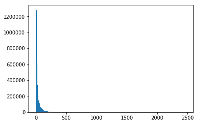

```python
bin_edges = np.arange(0, df_08['ArrDelay'].max()+10, 10)
plt.hist(data = df_08, x = 'ArrDelay',bins = bin_edges);
```

Let's increase the bin edge size and set an upper limit of 300 minutes so that the chart is more readable.

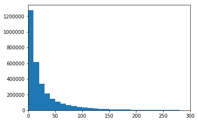

```python
bin_edges = np.arange(0, df_08['ArrDelay'].max()+10, 10)
plt.hist(data = df_08, x = 'ArrDelay',bins = bin_edges)
plt.xlim(0, 300);
```

```python
df_08.ArrDelay.max()
```

```
2461.0
```

```python
df_08[df_08['ArrDelay']>1500][['DepTime','CRSDepTime','ArrTime',
                               'CRSArrTime','ArrDelay','DepDelay','CarrierDelay',
                                'WeatherDelay','NASDelay','SecurityDelay','LateAircraftDelay']]
```

|  | DepTime | CRSDepTime | ArrTime | CRSArrTime | ArrDelay | DepDelay | CarrierDelay | WeatherDelay | NASDelay | SecurityDelay | LateAircraftDelay |
| --- | --- | --- | --- | --- | --- | --- | --- | --- | --- | --- | --- |
| 527950 | 800.0 | 1045 | 1452.0 | 1327 | 1525.0 | 1275.0 | 1158.0 | 0.0 | 117.0 | 0.0 | 250.0 |
| 1018798 | 1117.0 | 1820 | 2256.0 | 555 | 2461.0 | 2457.0 | 1455.0 | 0.0 | 4.0 | 0.0 | 1002.0 |
| 2232494 | 1818.0 | 1633 | 1942.0 | 1800 | 1542.0 | 1545.0 | 1542.0 | 0.0 | 0.0 | 0.0 | 0.0 |
| 2235378 | 724.0 | 1417 | 858.0 | 1605 | 2453.0 | 2467.0 | 2436.0 | 0.0 | 0.0 | 0.0 | 17.0 |
| 2832617 | 2.0 | 1530 | 254.0 | 1823 | 1951.0 | 1952.0 | 1951.0 | 0.0 | 0.0 | 0.0 | 0.0 |
| 3387883 | 2140.0 | 1710 | 2252.0 | 1825 | 1707.0 | 1710.0 | 1707.0 | 0.0 | 0.0 | 0.0 | 0.0 |
| 4061361 | 820.0 | 702 | 1325.0 | 1215 | 1510.0 | 1518.0 | 1510.0 | 0.0 | 0.0 | 0.0 | 0.0 |
| 5232546 | 906.0 | 714 | 1048.0 | 825 | 1583.0 | 1552.0 | 1552.0 | 0.0 | 31.0 | 0.0 | 0.0 |
| 6857047 | 1602.0 | 1325 | 1921.0 | 1546 | 1655.0 | 1597.0 | 1307.0 | 0.0 | 58.0 | 0.0 | 290.0 |

### Investigate Departure Delay in minutes

```python
df_08[(df_08['DepDelay'] < 15) & (df_08['DepDelay'] > 0)][['ArrDelay','DepDelay','CarrierDelay',
                                                           'WeatherDelay','NASDelay','SecurityDelay',
                                                          'LateAircraftDelay']].sample(10)
```

|  | ArrDelay | DepDelay | CarrierDelay | WeatherDelay | NASDelay | SecurityDelay | LateAircraftDelay |
| --- | --- | --- | --- | --- | --- | --- | --- |
| 306111 | -28.0 | 3.0 | NaN | NaN | NaN | NaN | NaN |
| 2788193 | -3.0 | 11.0 | NaN | NaN | NaN | NaN | NaN |
| 3527445 | 31.0 | 8.0 | 4.0 | 0.0 | 23.0 | 0.0 | 4.0 |
| 4720996 | -9.0 | 5.0 | NaN | NaN | NaN | NaN | NaN |
| 6274567 | 9.0 | 1.0 | NaN | NaN | NaN | NaN | NaN |
| 3479178 | 10.0 | 4.0 | NaN | NaN | NaN | NaN | NaN |
| 3341139 | -13.0 | 3.0 | NaN | NaN | NaN | NaN | NaN |
| 330915 | -5.0 | 4.0 | NaN | NaN | NaN | NaN | NaN |
| 1304933 | 11.0 | 7.0 | NaN | NaN | NaN | NaN | NaN |
| 4238213 | -6.0 | 1.0 | NaN | NaN | NaN | NaN | NaN |

DepDelay is not comprised of any of the delay causes. The sum of the 5 delay cause values only add up to ArrDelay. There is no mathematical relationship between the values of DepDelay and values of the 5 delay causes

```python
df_08[df_08['DepDelay'] >= 15][['ArrDelay','DepDelay','CarrierDelay','WeatherDelay','NASDelay','SecurityDelay',
                               'LateAircraftDelay']].sample(15)
```

|  | ArrDelay | DepDelay | CarrierDelay | WeatherDelay | NASDelay | SecurityDelay | LateAircraftDelay |
| --- | --- | --- | --- | --- | --- | --- | --- |
| 5939846 | 11.0 | 19.0 | NaN | NaN | NaN | NaN | NaN |
| 2359020 | 25.0 | 27.0 | 25.0 | 0.0 | 0.0 | 0.0 | 0.0 |
| 817382 | 29.0 | 33.0 | 8.0 | 0.0 | 0.0 | 0.0 | 21.0 |
| 405877 | 142.0 | 132.0 | 0.0 | 0.0 | 52.0 | 0.0 | 90.0 |
| 621419 | -11.0 | 16.0 | NaN | NaN | NaN | NaN | NaN |
| 1055027 | 91.0 | 68.0 | 0.0 | 0.0 | 83.0 | 0.0 | 8.0 |
| 1089768 | 74.0 | 55.0 | 55.0 | 0.0 | 19.0 | 0.0 | 0.0 |
| 1757546 | 53.0 | 57.0 | 6.0 | 0.0 | 0.0 | 0.0 | 47.0 |
| 100785 | 77.0 | 70.0 | 0.0 | 0.0 | 7.0 | 0.0 | 70.0 |
| 2108174 | 15.0 | 23.0 | 15.0 | 0.0 | 0.0 | 0.0 | 0.0 |
| 4483166 | 44.0 | 46.0 | 0.0 | 0.0 | 0.0 | 0.0 | 44.0 |
| 164039 | 2.0 | 15.0 | NaN | NaN | NaN | NaN | NaN |
| 3516346 | 37.0 | 33.0 | 0.0 | 0.0 | 4.0 | 0.0 | 33.0 |
| 6982057 | 29.0 | 28.0 | 0.0 | 0.0 | 13.0 | 0.0 | 16.0 |
| 6277027 | 73.0 | 78.0 | 73.0 | 0.0 | 0.0 | 0.0 | 0.0 |

```python
df_08.DepDelay.describe()
```

```
count    6.873482e+06
mean     1.000089e+01
std      3.493030e+01
min     -5.340000e+02
25%     -4.000000e+00
50%     -1.000000e+00
75%      8.000000e+00
max      2.467000e+03
Name: DepDelay, dtype: float64
```

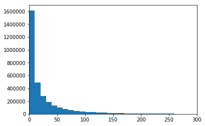

```python
bin_edges = np.arange(0, df_08['DepDelay'].max()+10, 10)
plt.hist(data = df_08, x = 'DepDelay',bins = bin_edges)
plt.xlim(0, 300);
```

```python
df_08.DepDelay.max()
```

```
2467.0
```

Departure delay has a long tailed distribution, with most of the delay happening at 60 minutes or less.

Next we'll look at a box plot of ArrDelay and DepDelay.

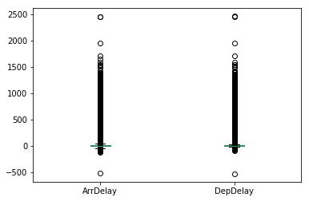

```python
df_08.loc[:,['ArrDelay', 'DepDelay']].plot.box();
```

Histograms for each of the delay categories in minutes.

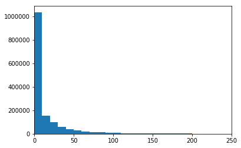

```python
# Carrier Delay histogram
bin_edges = np.arange(0, df_08['CarrierDelay'].max()+10, 10)
plt.hist(data = df_08, x = 'CarrierDelay',bins = bin_edges)
plt.xlim(0, 250);
```

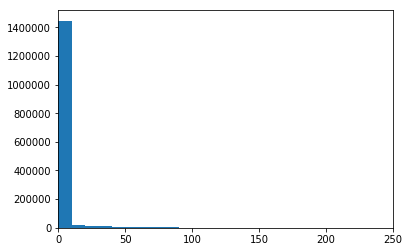

```python
# Weather Delay histogram
bin_edges = np.arange(0, df_08['WeatherDelay'].max()+10, 10)
plt.hist(data = df_08, x = 'WeatherDelay',bins = bin_edges)
plt.xlim(0, 250);
```

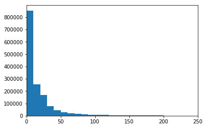

```python
# NAS Delay histogram
bin_edges = np.arange(0, df_08['NASDelay'].max()+10, 10)
plt.hist(data = df_08, x = 'NASDelay',bins = bin_edges)
plt.xlim(0, 250);
```

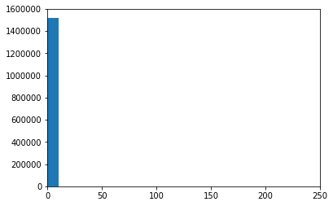

```python
# Security Delay histogram
bin_edges = np.arange(0, df_08['SecurityDelay'].max()+10, 10)
plt.hist(data = df_08, x = 'SecurityDelay',bins = bin_edges)
plt.xlim(0, 250);
```

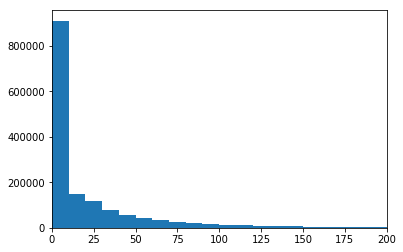

```python
# Late aircraft delay histogram
bin_edges = np.arange(0, df_08['LateAircraftDelay'].max()+10, 10)
plt.hist(data = df_08, x = 'LateAircraftDelay',bins = bin_edges)
plt.xlim(0, 200);
```

### Overall Percentages of Delayed Flights

FAA considers a flight to be delayed when it is 15 minutes later than its scheduled time. 22.2% and 19.3% of flights experience delays of 15 minutes or more, for arriving and departing flights, respectively.

```python
for x in df_08:
    df_08.loc[df_08['ArrDelay'] < 15, 'arr_status'] = 'Not Delayed'
    df_08.loc[df_08['ArrDelay'] >= 15, 'arr_status'] = 'Delayed'
    df_08.loc[df_08['DepDelay'] < 15, 'dep_status'] = 'Not Delayed'
    df_08.loc[df_08['DepDelay'] >= 15, 'dep_status'] = 'Delayed'
```

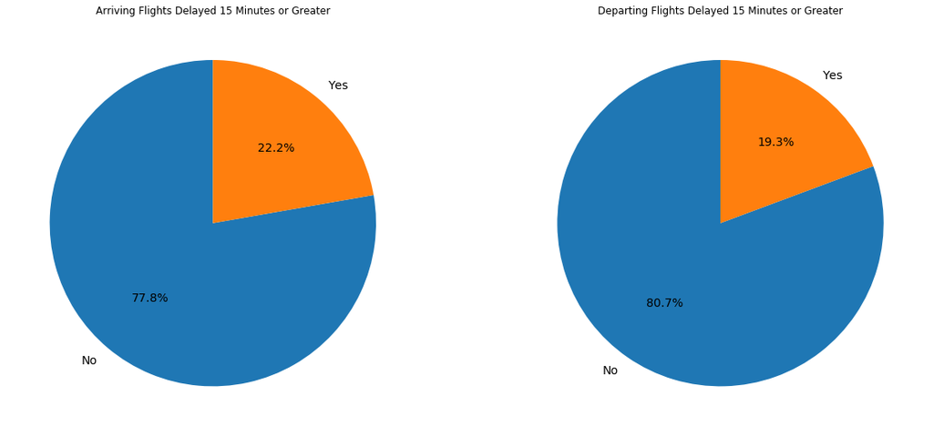

```python
f,ax=plt.subplots(1,2,figsize=(20,9))
df_08['arr_status'].value_counts().plot.pie(autopct='%1.1f%%',ax=ax[0],shadow=False, labels=['No','Yes'],startangle=90,
                                           textprops={'fontsize': 14})
ax[0].set_title('Arriving Flights Delayed 15 Minutes or Greater')
ax[0].set_ylabel('')

df_08['dep_status'].value_counts().plot.pie(autopct='%1.1f%%',ax=ax[1],shadow=False, labels=['No','Yes'],startangle=90,
                                           textprops={'fontsize': 14})
ax[1].set_title('Departing Flights Delayed 15 Minutes or Greater')
ax[1].set_ylabel('')

plt.show()
```

### Investigate Flight Distance

Next we will look at flight distance (measured in miles) between the origin and destination airport. This could be a predictor variable in how much flights are being delayed.

```python
df_08.Distance.describe()
```

```
count    7.009728e+06
mean     7.263870e+02
std      5.621018e+02
min      1.100000e+01
25%      3.250000e+02
50%      5.810000e+02
75%      9.540000e+02
max      4.962000e+03
Name: Distance, dtype: float64
```

The distribution of flight distance is right skewed, with most flights having a distance of 1500 miles or less. This makes sense the continental US is just under 3000 miles from coast to coast.

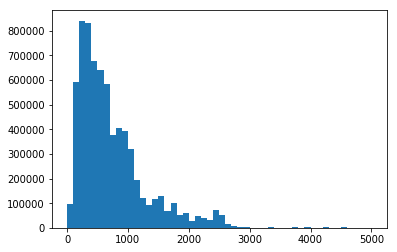

```python
bin_edges = np.arange(0, df_08['Distance'].max()+100, 100)
plt.hist(data = df_08, x = 'Distance',bins = bin_edges);
```

```python
df_08.Distance.max()
```

```
4962
```

```python
df_08[df_08['Distance']>3500]
```

|  | Year | Month | DayofMonth | DayOfWeek | DepTime | CRSDepTime | dep_hour | ArrTime | CRSArrTime | arr_hour | ... | LateAircraftDelay | Origin | airport_origin | origin_state | Dest | airport_dest | dest_state | DepDate | arr_status | dep_status |
| --- | --- | --- | --- | --- | --- | --- | --- | --- | --- | --- | --- | --- | --- | --- | --- | --- | --- | --- | --- | --- | --- |
| 218178 | 2008 | 1 | 1 | 2 | 1030.0 | 1010 | 10 | 1541.0 | 1522 | 15 | ... | 0.0 | ORD | Chicago O'Hare International | IL | HNL | Honolulu International | HI | 2008-01-01 | Delayed | Delayed |
| 218179 | 2008 | 1 | 2 | 3 | 1037.0 | 1010 | 10 | 1535.0 | 1522 | 15 | ... | NaN | ORD | Chicago O'Hare International | IL | HNL | Honolulu International | HI | 2008-01-02 | Not Delayed | Delayed |
| 218180 | 2008 | 1 | 3 | 4 | 1028.0 | 1010 | 10 | 1515.0 | 1522 | 15 | ... | NaN | ORD | Chicago O'Hare International | IL | HNL | Honolulu International | HI | 2008-01-03 | Not Delayed | Delayed |
| 218181 | 2008 | 1 | 4 | 5 | 1013.0 | 1010 | 10 | 1544.0 | 1522 | 15 | ... | 0.0 | ORD | Chicago O'Hare International | IL | HNL | Honolulu International | HI | 2008-01-04 | Delayed | Not Delayed |
| 218182 | 2008 | 1 | 5 | 6 | 1129.0 | 1010 | 10 | 1700.0 | 1522 | 15 | ... | 0.0 | ORD | Chicago O'Hare International | IL | HNL | Honolulu International | HI | 2008-01-05 | Delayed | Delayed |
| 218183 | 2008 | 1 | 6 | 7 | 1038.0 | 1010 | 10 | 1554.0 | 1522 | 15 | ... | 0.0 | ORD | Chicago O'Hare International | IL | HNL | Honolulu International | HI | 2008-01-06 | Delayed | Delayed |
| 218184 | 2008 | 1 | 7 | 1 | 1025.0 | 1025 | 10 | 1539.0 | 1541 | 15 | ... | NaN | ORD | Chicago O'Hare International | IL | HNL | Honolulu International | HI | 2008-01-07 | Not Delayed | Not Delayed |
| 218185 | 2008 | 1 | 8 | 2 | 1025.0 | 1025 | 10 | 1530.0 | 1541 | 15 | ... | NaN | ORD | Chicago O'Hare International | IL | HNL | Honolulu International | HI | 2008-01-08 | Not Delayed | Not Delayed |
| 218186 | 2008 | 1 | 9 | 3 | 1148.0 | 1025 | 10 | 1704.0 | 1541 | 15 | ... | 0.0 | ORD | Chicago O'Hare International | IL | HNL | Honolulu International | HI | 2008-01-09 | Delayed | Delayed |
| 218187 | 2008 | 1 | 10 | 4 | 1022.0 | 1025 | 10 | 1541.0 | 1541 | 15 | ... | NaN | ORD | Chicago O'Hare International | IL | HNL | Honolulu International | HI | 2008-01-10 | Not Delayed | Not Delayed |
| 218188 | 2008 | 1 | 11 | 5 | 1021.0 | 1025 | 10 | 1524.0 | 1541 | 15 | ... | NaN | ORD | Chicago O'Hare International | IL | HNL | Honolulu International | HI | 2008-01-11 | Not Delayed | Not Delayed |
| 218189 | 2008 | 1 | 12 | 6 | 1051.0 | 1020 | 10 | 1603.0 | 1536 | 15 | ... | 0.0 | ORD | Chicago O'Hare International | IL | HNL | Honolulu International | HI | 2008-01-12 | Delayed | Delayed |
| 218190 | 2008 | 1 | 13 | 7 | 1026.0 | 1025 | 10 | 1533.0 | 1541 | 15 | ... | NaN | ORD | Chicago O'Hare International | IL | HNL | Honolulu International | HI | 2008-01-13 | Not Delayed | Not Delayed |
| 218191 | 2008 | 1 | 14 | 1 | 1020.0 | 1025 | 10 | 1531.0 | 1541 | 15 | ... | NaN | ORD | Chicago O'Hare International | IL | HNL | Honolulu International | HI | 2008-01-14 | Not Delayed | Not Delayed |
| 218192 | 2008 | 1 | 15 | 2 | 1148.0 | 1025 | 10 | 1631.0 | 1541 | 15 | ... | 0.0 | ORD | Chicago O'Hare International | IL | HNL | Honolulu International | HI | 2008-01-15 | Delayed | Delayed |
| 218193 | 2008 | 1 | 16 | 3 | 1025.0 | 1025 | 10 | 1500.0 | 1541 | 15 | ... | NaN | ORD | Chicago O'Hare International | IL | HNL | Honolulu International | HI | 2008-01-16 | Not Delayed | Not Delayed |
| 218194 | 2008 | 1 | 17 | 4 | 1024.0 | 1025 | 10 | 1529.0 | 1541 | 15 | ... | NaN | ORD | Chicago O'Hare International | IL | HNL | Honolulu International | HI | 2008-01-17 | Not Delayed | Not Delayed |
| 218195 | 2008 | 1 | 18 | 5 | 1024.0 | 1025 | 10 | 1520.0 | 1541 | 15 | ... | NaN | ORD | Chicago O'Hare International | IL | HNL | Honolulu International | HI | 2008-01-18 | Not Delayed | Not Delayed |
| 218196 | 2008 | 1 | 19 | 6 | 1123.0 | 1020 | 10 | 1555.0 | 1536 | 15 | ... | 0.0 | ORD | Chicago O'Hare International | IL | HNL | Honolulu International | HI | 2008-01-19 | Delayed | Delayed |
| 218197 | 2008 | 1 | 20 | 7 | 1107.0 | 1025 | 10 | 1554.0 | 1541 | 15 | ... | NaN | ORD | Chicago O'Hare International | IL | HNL | Honolulu International | HI | 2008-01-20 | Not Delayed | Delayed |
| 218198 | 2008 | 1 | 21 | 1 | 1025.0 | 1025 | 10 | 1511.0 | 1541 | 15 | ... | NaN | ORD | Chicago O'Hare International | IL | HNL | Honolulu International | HI | 2008-01-21 | Not Delayed | Not Delayed |
| 218199 | 2008 | 1 | 22 | 2 | 1027.0 | 1025 | 10 | 1511.0 | 1541 | 15 | ... | NaN | ORD | Chicago O'Hare International | IL | HNL | Honolulu International | HI | 2008-01-22 | Not Delayed | Not Delayed |
| 218200 | 2008 | 1 | 23 | 3 | 1024.0 | 1025 | 10 | 1502.0 | 1541 | 15 | ... | NaN | ORD | Chicago O'Hare International | IL | HNL | Honolulu International | HI | 2008-01-23 | Not Delayed | Not Delayed |
| 218201 | 2008 | 1 | 24 | 4 | 1024.0 | 1025 | 10 | 1454.0 | 1541 | 15 | ... | NaN | ORD | Chicago O'Hare International | IL | HNL | Honolulu International | HI | 2008-01-24 | Not Delayed | Not Delayed |
| 218202 | 2008 | 1 | 25 | 5 | 1029.0 | 1025 | 10 | 1444.0 | 1541 | 15 | ... | NaN | ORD | Chicago O'Hare International | IL | HNL | Honolulu International | HI | 2008-01-25 | Not Delayed | Not Delayed |
| 218203 | 2008 | 1 | 26 | 6 | 1024.0 | 1020 | 10 | 1516.0 | 1536 | 15 | ... | NaN | ORD | Chicago O'Hare International | IL | HNL | Honolulu International | HI | 2008-01-26 | Not Delayed | Not Delayed |
| 218204 | 2008 | 1 | 27 | 7 | 1021.0 | 1025 | 10 | 1519.0 | 1541 | 15 | ... | NaN | ORD | Chicago O'Hare International | IL | HNL | Honolulu International | HI | 2008-01-27 | Not Delayed | Not Delayed |
| 218205 | 2008 | 1 | 28 | 1 | 1022.0 | 1025 | 10 | 1510.0 | 1541 | 15 | ... | NaN | ORD | Chicago O'Hare International | IL | HNL | Honolulu International | HI | 2008-01-28 | Not Delayed | Not Delayed |
| 218206 | 2008 | 1 | 29 | 2 | 1025.0 | 1025 | 10 | 1531.0 | 1541 | 15 | ... | NaN | ORD | Chicago O'Hare International | IL | HNL | Honolulu International | HI | 2008-01-29 | Not Delayed | Not Delayed |
| 218207 | 2008 | 1 | 30 | 3 | 1230.0 | 1025 | 10 | 1730.0 | 1541 | 15 | ... | 0.0 | ORD | Chicago O'Hare International | IL | HNL | Honolulu International | HI | 2008-01-30 | Delayed | Delayed |
| ... | ... | ... | ... | ... | ... | ... | ... | ... | ... | ... | ... | ... | ... | ... | ... | ... | ... | ... | ... | ... | ... |
| 6993152 | 2008 | 12 | 1 | 1 | 2059.0 | 2055 | 20 | 1138.0 | 1120 | 11 | ... | 0.0 | HNL | Honolulu International | HI | EWR | Newark Intl | NJ | 2008-12-01 | Delayed | Not Delayed |
| 6993153 | 2008 | 12 | 1 | 1 | 1340.0 | 1335 | 13 | 1929.0 | 1935 | 19 | ... | NaN | EWR | Newark Intl | NJ | HNL | Honolulu International | HI | 2008-12-01 | Not Delayed | Not Delayed |
| 6993170 | 2008 | 12 | 1 | 1 | 2201.0 | 2205 | 22 | 946.0 | 945 | 9 | ... | NaN | HNL | Honolulu International | HI | IAH | George Bush Intercontinental | TX | 2008-12-01 | Not Delayed | Not Delayed |
| 6993171 | 2008 | 12 | 1 | 1 | 1136.0 | 1120 | 11 | 1555.0 | 1550 | 15 | ... | NaN | IAH | George Bush Intercontinental | TX | HNL | Honolulu International | HI | 2008-12-01 | Not Delayed | Delayed |
| 6994798 | 2008 | 12 | 1 | 1 | 1035.0 | 1035 | 10 | 1531.0 | 1515 | 15 | ... | 0.0 | ATL | William B Hartsfield-Atlanta Intl | GA | HNL | Honolulu International | HI | 2008-12-01 | Delayed | Not Delayed |
| 6994809 | 2008 | 12 | 1 | 1 | 1653.0 | 1650 | 16 | 636.0 | 632 | 6 | ... | NaN | HNL | Honolulu International | HI | ATL | William B Hartsfield-Atlanta Intl | GA | 2008-12-01 | Not Delayed | Not Delayed |
| 6996058 | 2008 | 12 | 2 | 2 | 1038.0 | 1035 | 10 | 1526.0 | 1515 | 15 | ... | NaN | ATL | William B Hartsfield-Atlanta Intl | GA | HNL | Honolulu International | HI | 2008-12-02 | Not Delayed | Not Delayed |
| 6996068 | 2008 | 12 | 2 | 2 | 1653.0 | 1650 | 16 | 632.0 | 632 | 6 | ... | NaN | HNL | Honolulu International | HI | ATL | William B Hartsfield-Atlanta Intl | GA | 2008-12-02 | Not Delayed | Not Delayed |
| 6997307 | 2008 | 12 | 3 | 3 | 1031.0 | 1035 | 10 | 1504.0 | 1515 | 15 | ... | NaN | ATL | William B Hartsfield-Atlanta Intl | GA | HNL | Honolulu International | HI | 2008-12-03 | Not Delayed | Not Delayed |
| 6997318 | 2008 | 12 | 3 | 3 | 1703.0 | 1650 | 16 | 709.0 | 632 | 6 | ... | 0.0 | HNL | Honolulu International | HI | ATL | William B Hartsfield-Atlanta Intl | GA | 2008-12-03 | Delayed | Not Delayed |
| 6998602 | 2008 | 12 | 4 | 4 | 1046.0 | 1035 | 10 | 1505.0 | 1515 | 15 | ... | NaN | ATL | William B Hartsfield-Atlanta Intl | GA | HNL | Honolulu International | HI | 2008-12-04 | Not Delayed | Not Delayed |
| 6998613 | 2008 | 12 | 4 | 4 | 1650.0 | 1650 | 16 | 623.0 | 632 | 6 | ... | NaN | HNL | Honolulu International | HI | ATL | William B Hartsfield-Atlanta Intl | GA | 2008-12-04 | Not Delayed | Not Delayed |
| 6999919 | 2008 | 12 | 5 | 5 | 1044.0 | 1035 | 10 | 1503.0 | 1515 | 15 | ... | NaN | ATL | William B Hartsfield-Atlanta Intl | GA | HNL | Honolulu International | HI | 2008-12-05 | Not Delayed | Not Delayed |
| 6999930 | 2008 | 12 | 5 | 5 | 1647.0 | 1650 | 16 | 646.0 | 632 | 6 | ... | NaN | HNL | Honolulu International | HI | ATL | William B Hartsfield-Atlanta Intl | GA | 2008-12-05 | Not Delayed | Not Delayed |
| 7001063 | 2008 | 12 | 6 | 6 | 1032.0 | 1035 | 10 | 1504.0 | 1515 | 15 | ... | NaN | ATL | William B Hartsfield-Atlanta Intl | GA | HNL | Honolulu International | HI | 2008-12-06 | Not Delayed | Not Delayed |
| 7001071 | 2008 | 12 | 6 | 6 | 1643.0 | 1650 | 16 | 633.0 | 632 | 6 | ... | NaN | HNL | Honolulu International | HI | ATL | William B Hartsfield-Atlanta Intl | GA | 2008-12-06 | Not Delayed | Not Delayed |
| 7002156 | 2008 | 12 | 7 | 7 | 1026.0 | 1035 | 10 | 1501.0 | 1515 | 15 | ... | NaN | ATL | William B Hartsfield-Atlanta Intl | GA | HNL | Honolulu International | HI | 2008-12-07 | Not Delayed | Not Delayed |
| 7002164 | 2008 | 12 | 7 | 7 | 1644.0 | 1650 | 16 | 620.0 | 632 | 6 | ... | NaN | HNL | Honolulu International | HI | ATL | William B Hartsfield-Atlanta Intl | GA | 2008-12-07 | Not Delayed | Not Delayed |
| 7003400 | 2008 | 12 | 8 | 1 | 1036.0 | 1035 | 10 | 1505.0 | 1515 | 15 | ... | NaN | ATL | William B Hartsfield-Atlanta Intl | GA | HNL | Honolulu International | HI | 2008-12-08 | Not Delayed | Not Delayed |
| 7003411 | 2008 | 12 | 8 | 1 | 1647.0 | 1650 | 16 | 631.0 | 632 | 6 | ... | NaN | HNL | Honolulu International | HI | ATL | William B Hartsfield-Atlanta Intl | GA | 2008-12-08 | Not Delayed | Not Delayed |
| 7004673 | 2008 | 12 | 9 | 2 | 1059.0 | 1035 | 10 | 1530.0 | 1515 | 15 | ... | 15.0 | ATL | William B Hartsfield-Atlanta Intl | GA | HNL | Honolulu International | HI | 2008-12-09 | Delayed | Delayed |
| 7004682 | 2008 | 12 | 9 | 2 | 1649.0 | 1650 | 16 | 701.0 | 632 | 6 | ... | 0.0 | HNL | Honolulu International | HI | ATL | William B Hartsfield-Atlanta Intl | GA | 2008-12-09 | Delayed | Not Delayed |
| 7005928 | 2008 | 12 | 10 | 3 | 1149.0 | 1035 | 10 | 1627.0 | 1515 | 15 | ... | 72.0 | ATL | William B Hartsfield-Atlanta Intl | GA | HNL | Honolulu International | HI | 2008-12-10 | Delayed | Delayed |
| 7005939 | 2008 | 12 | 10 | 3 | 1650.0 | 1650 | 16 | 640.0 | 632 | 6 | ... | NaN | HNL | Honolulu International | HI | ATL | William B Hartsfield-Atlanta Intl | GA | 2008-12-10 | Not Delayed | Not Delayed |
| 7007213 | 2008 | 12 | 11 | 4 | 1229.0 | 1035 | 10 | 1644.0 | 1515 | 15 | ... | 0.0 | ATL | William B Hartsfield-Atlanta Intl | GA | HNL | Honolulu International | HI | 2008-12-11 | Delayed | Delayed |
| 7007224 | 2008 | 12 | 11 | 4 | 1720.0 | 1650 | 16 | 708.0 | 632 | 6 | ... | 23.0 | HNL | Honolulu International | HI | ATL | William B Hartsfield-Atlanta Intl | GA | 2008-12-11 | Delayed | Delayed |
| 7008525 | 2008 | 12 | 12 | 5 | 1057.0 | 1035 | 10 | 1541.0 | 1515 | 15 | ... | 22.0 | ATL | William B Hartsfield-Atlanta Intl | GA | HNL | Honolulu International | HI | 2008-12-12 | Delayed | Delayed |
| 7008536 | 2008 | 12 | 12 | 5 | 1714.0 | 1650 | 16 | 647.0 | 632 | 6 | ... | 15.0 | HNL | Honolulu International | HI | ATL | William B Hartsfield-Atlanta Intl | GA | 2008-12-12 | Delayed | Delayed |
| 7009502 | 2008 | 12 | 13 | 6 | 1035.0 | 1035 | 10 | 1542.0 | 1535 | 15 | ... | NaN | ATL | William B Hartsfield-Atlanta Intl | GA | HNL | Honolulu International | HI | 2008-12-13 | Not Delayed | Not Delayed |
| 7009511 | 2008 | 12 | 13 | 6 | 1710.0 | 1705 | 17 | 633.0 | 640 | 6 | ... | NaN | HNL | Honolulu International | HI | ATL | William B Hartsfield-Atlanta Intl | GA | 2008-12-13 | Not Delayed | Not Delayed |

8054 rows × 34 columns

### Investigate cancelled flights and cancellation causes

Next we look at the number of cancelled flights in the dataset.

```python
df_08['Cancelled'].value_counts()
```

```
0    6872294
1     137434
Name: Cancelled, dtype: int64
```

```python
# create dataframe for cancelled flights
#cancelled = df_08[df_08['Cancelled'] == 1]
```

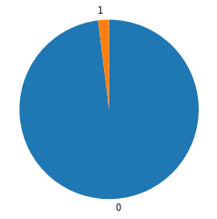

```python
# Pie for for cancelled (1) vs not cancelled (0) flights
sorted_counts = df_08['Cancelled'].value_counts()
plt.pie(sorted_counts, labels = sorted_counts.index, startangle = 90,
        counterclock = False);
plt.axis('square');
```

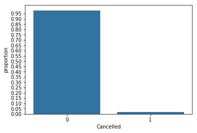

```python
# get proportion taken by most common group for derivation
# of tick marks
n_points = df_08.shape[0]
max_count = df_08['Cancelled'].value_counts().max()
max_prop = max_count / n_points

# generate tick mark locations and names
tick_props = np.arange(0, max_prop, 0.05)
tick_names = ['{:0.2f}'.format(v) for v in tick_props]

# create the plot
base_color = sb.color_palette()[0]
sb.countplot(data = df_08, x = 'Cancelled', color = base_color)
plt.yticks(tick_props * n_points, tick_names)
plt.ylabel('proportion')
```

Cancelled flights account for roughly 2% of all scheduled US domestic flights in 2008.

Earlier in the data wrangling section I replaced the letter based cancellation codes with the appropriate reasons as stated in the dataset description (A=Carrier, B=Weather, C=NAS, D=Security)

```python
df_08['CancellationCode'].value_counts()
```

```
Weather     54904
Carrier     54330
NAS         28188
Security       12
Name: CancellationCode, dtype: int64
```

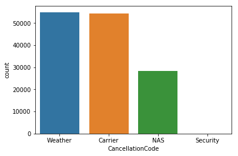

```python
cat_order = df_08['CancellationCode'].value_counts().index
sb.countplot(data = df_08, x = 'CancellationCode', order = cat_order);
```

Cancellation due to carrier and weather occurs roughly at frequency, where NAS occurs at half the frequency of carrier and weather.

### Investigate diverted flights

Using the same technique as the preivous section with cancelled flights, we examine the number of diverted flights in the dataset.

```python
# create dataframe for diverted flights
#diverted = df_08[df_08['Diverted'] == 1]
```

```python
df_08['Diverted'].value_counts()
```

```
0    6992463
1      17265
Name: Diverted, dtype: int64
```

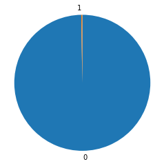

```python
# Pie for for diverted (1) vs not diverted (0) flights
sorted_counts = df_08['Diverted'].value_counts()
plt.pie(sorted_counts, labels = sorted_counts.index, startangle = 90,
        counterclock = False);
plt.axis('square');
```

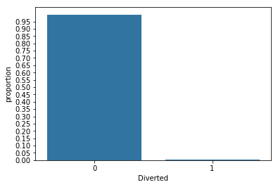

```python
# get proportion taken by most common group for derivation
# of tick marks
n_points = df_08.shape[0]
max_count = df_08['Diverted'].value_counts().max()
max_prop = max_count / n_points

# generate tick mark locations and names
tick_props = np.arange(0, max_prop, 0.05)
tick_names = ['{:0.2f}'.format(v) for v in tick_props]

# create the plot
base_color = sb.color_palette()[0]
sb.countplot(data = df_08, x = 'Diverted', color = base_color)
plt.yticks(tick_props * n_points, tick_names)
plt.ylabel('proportion')
```

Diverted flights only account for less than 0.25% of all scheduled US domestic flights in 2018.

### Top 30 Airports by Number of Scheduled Flights

Next, we will examine both origin and destination aiports in terms of the number of scheduled flights.

```python
#df_08['airport_origin'].value_counts().head(10)
```

```python
#df_08['airport_dest'].value_counts().head(10)
```

Below we can see the top 30 airports in terms of number of arriving and departing flights for 2008. Not suprisingly the top 10 list is the same for both origin and destination airports, with Atlanta holding on to the #1 spot, followed by Chicago O'Hare and Dallas Fort Worth.

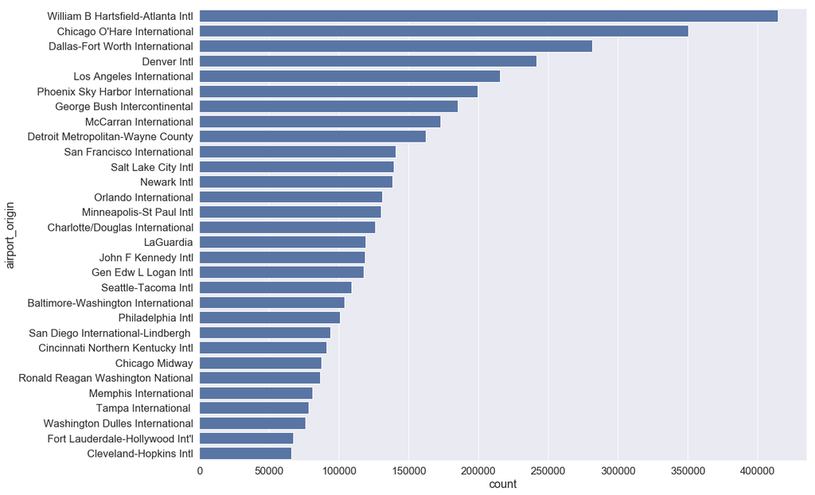

```python
plt.figure(figsize=(17,13))
sb.set(font_scale=1.5)
base_color = sb.color_palette()[0]
ax=sb.countplot(data = df_08, y = 'airport_origin', color = base_color,
             order=df_08['airport_origin'].value_counts().iloc[:30].index);
```

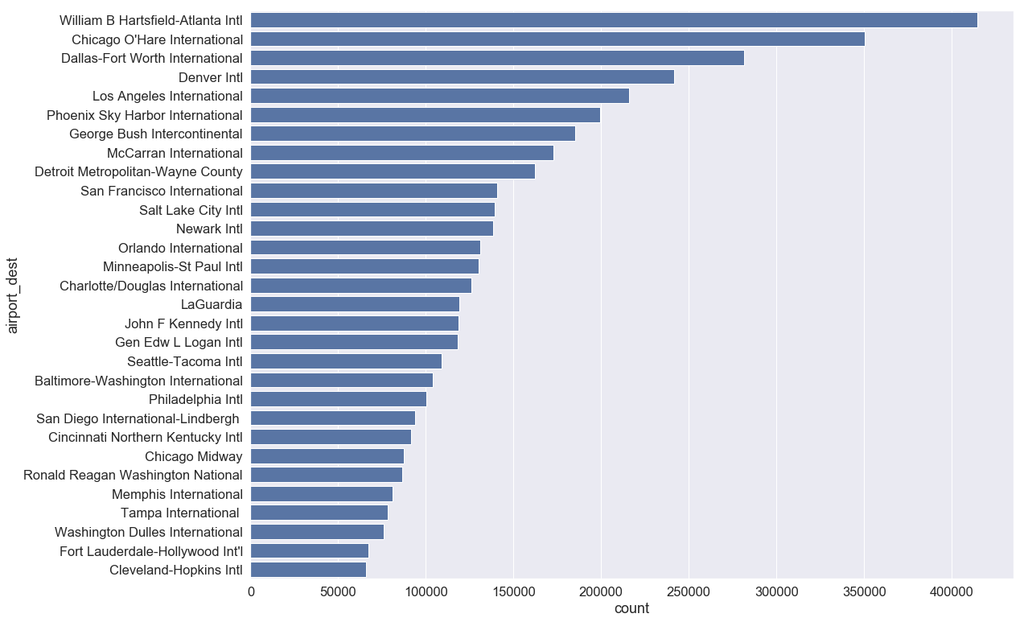

```python
plt.figure(figsize=(17,13))
base_color = sb.color_palette()[0]
ax = sb.countplot(data = df_08, y = 'airport_dest', color = base_color,
             order=df_08['airport_dest'].value_counts().iloc[:30].index);
```

### Investigate flight count by day of week

Note: 1 = Monday, 2 = Tuesday, 3 = Wednesday, 4 = Thursday, 5 = Friday, 6 = Saturday, 7 = Sunday

Weekdays have about the same number of scheduled flights, and is what I would expect because of business travellers. Saturday has the least amount of scheduled flights.

```python
sb.set(font_scale=1)
```

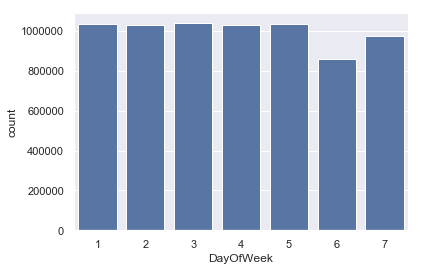

```python
base_color = sb.color_palette()[0]
sb.countplot(data = df_08, x = 'DayOfWeek', color = base_color);
```

### Investigate flight count by month

July, March and August are the busiest months for number of scheduled flights in 2008, while November, September and December are the least busy months. I would have thought that December will have high numbers because of Christmas and November because of Thanksgiving. Airlines tend to schedule more flights in the warmer months.

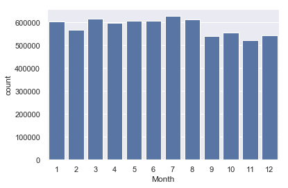

```python
base_color = sb.color_palette()[0]
sb.countplot(data = df_08, x = 'Month', color = base_color);
```

### Investigate flight count by departure hour

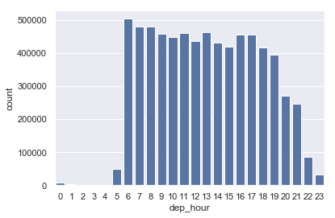

```python
base_color = sb.color_palette()[0]
sb.countplot(data = df_08, x = 'dep_hour', color = base_color);
```

There are a suprising amount of departing flights early on during the day at 6am and 7am.

### Investigate flight count by arrival hour

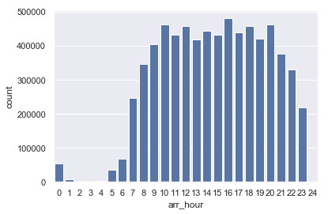

```python
base_color = sb.color_palette()[0]
sb.countplot(data = df_08, x = 'arr_hour', color = base_color);
```

Arriving flight hours seems to match what I would expect, with flights fairly evenly distributed between the hours of 11am and 8pm each day.

### Investigate number of flights by airline

Southwest by far has the largest number of scheduled flights in 2008!

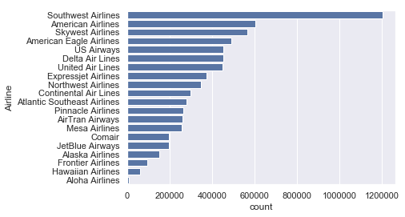

```python
sb.countplot(data = df_08, y = 'Airline', color = base_color,order=df_08['Airline'].value_counts().index );
```

### Discuss the distribution(s) of your variable(s) of interest. Were there any unusual points? Did you need to perform any transformations?

I created some additional columns (arr_hour, dep_hour) to get the hour of day from the scheduled time (CRSArrTime, CRSDepTime) for arriving and departing flights respectively. Flights with arr_hour=24 indicates that the flight was diverted and never arrived to its original destination.

Also more columns were added for the airport and airline names, and DepDate to show the departing date in YYYY-mm-dd format.

### Of the features you investigated, were there any unusual distributions? Did you perform any operations on the data to tidy, adjust, or change the form of the data? If so, why did you do this?

There are a suprising amount of departing flights early on during the day at 6am and 7am, where I would assume there to be less flights than later on during the day. In terms of cancellation reason, I expected a majority of cancellations to be from weather. However, it looks like the airlines cancel flights at roughly the same number as ones due to weather.

## Bivariate Exploration

### Relationship between arrival delay and departure delay

I started off with a scatter plot to see the relationship between arrival and departure delay values. Most of the data from the scatter plot falls between 0 and 1500 for ArrDelay and DepDelay, and shows a fairly high correlation between the 2 delay values in minutes.

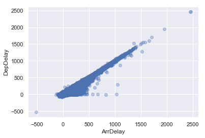

```python
sb.regplot(data = df_08, x = 'ArrDelay', y = 'DepDelay', fit_reg = False,
           x_jitter = 0.2, y_jitter = 0.2, scatter_kws = {'alpha' : 1/3})
```

```
(0, 1000)
```

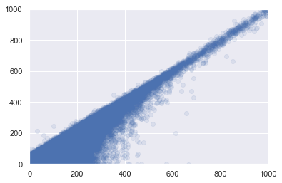

```python
plt.scatter(data = df_08, x = 'ArrDelay', y = 'DepDelay', alpha=0.1)
plt.xlim(0,1000)
plt.ylim(0,1000)
```

There are definitely more delays for shorter distance flights (between 0 and 2000 miles), but they also happen much more often as many flights are under 2000 miles within the US.

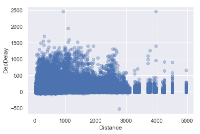

```python
sb.regplot(data = df_08, x = 'Distance', y = 'DepDelay', fit_reg = False,
           x_jitter = 0.2, y_jitter = 0.2, scatter_kws = {'alpha' : 1/3});
```

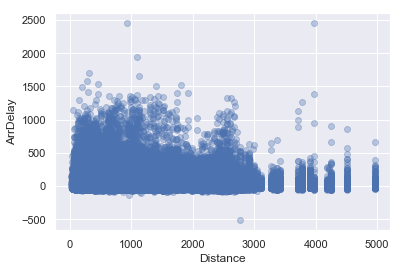

```python
sb.regplot(data = df_08, x = 'Distance', y = 'ArrDelay', fit_reg = False,
           x_jitter = 0.2, y_jitter = 0.2, scatter_kws = {'alpha' : 1/3});
```

### Mean Arrival and Departure Delay vs Airport

Next let's take a examine the relationship between delay and airport. Which airports are more susceptible to delays? Here I pair the origin airport with departure delay and destination airport with arrival delay.

#### Top 10 origin airports with the highest average departure delay (in minutes)

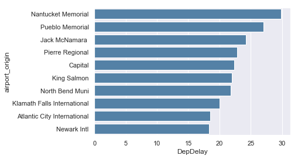

```python
sb.barplot(x=df_08.groupby('airport_origin').DepDelay.mean().sort_values(ascending=False).head(10)
           , y=df_08.groupby('airport_origin').DepDelay.mean().sort_values(ascending=False).head(10).index, color='steelblue');
```

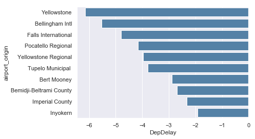

```python
sb.barplot(x=df_08.groupby('airport_origin').DepDelay.mean().sort_values().head(10)
           , y=df_08.groupby('airport_origin').DepDelay.mean().sort_values().head(10).index, color='steelblue');
```

#### Top 10 destination airports with the highest average arrival delay (in minutes)

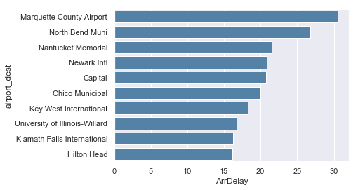

```python
sb.barplot(x=df_08.groupby('airport_dest').ArrDelay.mean().sort_values(ascending=False).head(10)
           , y=df_08.groupby('airport_dest').ArrDelay.mean().sort_values(ascending=False).head(10).index, color='steelblue');
```

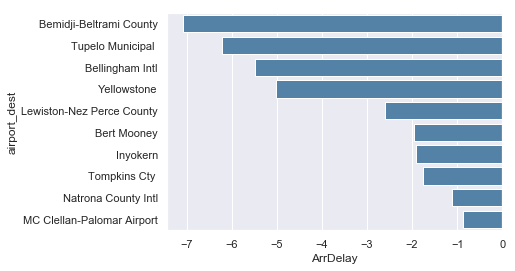

```python
sb.barplot(x=df_08.groupby('airport_dest').ArrDelay.mean().sort_values().head(10)
           , y=df_08.groupby('airport_dest').ArrDelay.mean().sort_values().head(10).index, color='steelblue');
```